# **PCFL 2023: Week 4 wrap-up**

Week 4 is a wrap!

The bye weeks have arrived y’all. Check your lineups!!

## Last week’s games

| Winner | Winner’s score | Loser | Loser’s score |
| --- | --- | --- | --- |
| Georgia Peanuts | 148.64 | KC Gophers | 72.72 |
| Southern Sharks | 117.90 | Middle Earth Hangry Hobbits | 70.74 |
| Athens Team Sasquatch | 91.48 | The G.O.A.T. | 88.70 |
| Pigskin on the Gridiron | 117.40 | The Seniors | 115.81 |
| Jumpin’ Jaheims | 149.98 | Captain Clairvoyant | 83.52 |

The Peanuts finally won! (And some of you also did, too. Evan had an OK week.)

## Best performances

### Best players overall

Here’s last week’s **10 best performing starters.**

| Player | Position | NFL Team | Points | PCFL Team |
| --- | --- | --- | --- | --- |
| Christian McCaffrey | RB | SFO | 45.20 | The Seniors |
| Josh Allen | QB | BUF | 36.50 | The G.O.A.T. |
| A.J. Brown | WR | PHI | 35.00 | Georgia Peanuts |
| Stefon Diggs | WR | BUF | 34.00 | Jumpin’ Jaheims |
| Anthony Richardson | QB | IND | 29.60 | Southern Sharks |
| Seahawks D/ST | DST | SEA | 29.00 | KC Gophers |
| Lamar Jackson | QB | BAL | 28.14 | Middle Earth Hangry Hobbits |
| Justin Fields | QB | CHI | 27.90 | Pigskin on the Gridiron |
| Puka Nacua | WR | LAR | 26.80 | Jumpin’ Jaheims |
| Kyren Williams | RB/WR/TE | LAR | 26.20 | Athens Team Sasquatch |

Christian McCaffrey was the correct answer for the best first round choice, clearly. Nice job, Seniors. And check out rookie Anthony Richardson making the list.

### Best players per team

Here’s last week’s top players **on each team.**

| Player | Position | NFL Team | Points | PCFL Team |
| --- | --- | --- | --- | --- |
| Kyren Williams | RB/WR/TE | LAR | 26.20 | Athens Team Sasquatch |
| Josh Jacobs | RB | OAK | 23.90 | Captain Clairvoyant |
| A.J. Brown | WR | PHI | 35.00 | Georgia Peanuts |
| Stefon Diggs | WR | BUF | 34.00 | Jumpin’ Jaheims |
| Seahawks D/ST | DST | SEA | 29.00 | KC Gophers |
| Lamar Jackson | QB | BAL | 28.14 | Middle Earth Hangry Hobbits |
| Justin Fields | QB | CHI | 27.90 | Pigskin on the Gridiron |
| Anthony Richardson | QB | IND | 29.60 | Southern Sharks |
| Josh Allen | QB | BUF | 36.50 | The G.O.A.T. |
| Christian McCaffrey | RB | SFO | 45.20 | The Seniors |

### Best bench

Who won the **best scoring bench** award last week?

| Team | Bench points |
| --- | --- |
| Georgia Peanuts | 75.74 |
| The Seniors | 75.06 |
| Athens Team Sasquatch | 72.06 |
| Captain Clairvoyant | 69.98 |
| KC Gophers | 69.90 |
| Jumpin’ Jaheims | 69.90 |
| Southern Sharks | 61.20 |
| Pigskin on the Gridiron | 48.99 |
| The G.O.A.T. | 47.52 |
| Middle Earth Hangry Hobbits | 28.88 |

Yay, Peanuts!

Here’s the season’s bench standings:

| Team | Bench points |
| --- | --- |
| Georgia Peanuts | 292.78 |
| Southern Sharks | 286.56 |
| The Seniors | 280.21 |
| Athens Team Sasquatch | 252.81 |
| Jumpin’ Jaheims | 248.50 |
| Middle Earth Hangry Hobbits | 247.48 |
| KC Gophers | 221.70 |
| Captain Clairvoyant | 218.62 |
| Pigskin on the Gridiron | 210.37 |
| The G.O.A.T. | 162.16 |

Sarah’s in second, but probably not for long.

### Best optimized lineups

I compared the actual starting lineups for each team to the hypothetical *best* starting lineup the owner could have started. The table below shows the actual points the team scored, the top score they could have had, and an “optimization” percentage that compares to the two.

| PCFL Team | Actual points | Best lineup | Optimization rate |
| --- | --- | --- | --- |
| Middle Earth Hangry Hobbits | 70.74 | 70.74 | 100% |
| Georgia Peanuts | 148.64 | 164.84 | 90% |
| Pigskin on the Gridiron | 117.40 | 129.90 | 90% |
| Southern Sharks | 117.90 | 131.00 | 90% |
| Jumpin’ Jaheims | 149.98 | 176.18 | 85% |
| The G.O.A.T. | 88.70 | 109.50 | 81% |
| Athens Team Sasquatch | 91.48 | 117.84 | 78% |
| Captain Clairvoyant | 83.52 | 113.22 | 74% |
| The Seniors | 115.81 | 156.96 | 74% |
| KC Gophers | 72.72 | 118.42 | 61% |

For the *whole season*, here’s a graph of actual points scored vs. optimized points given the roster.

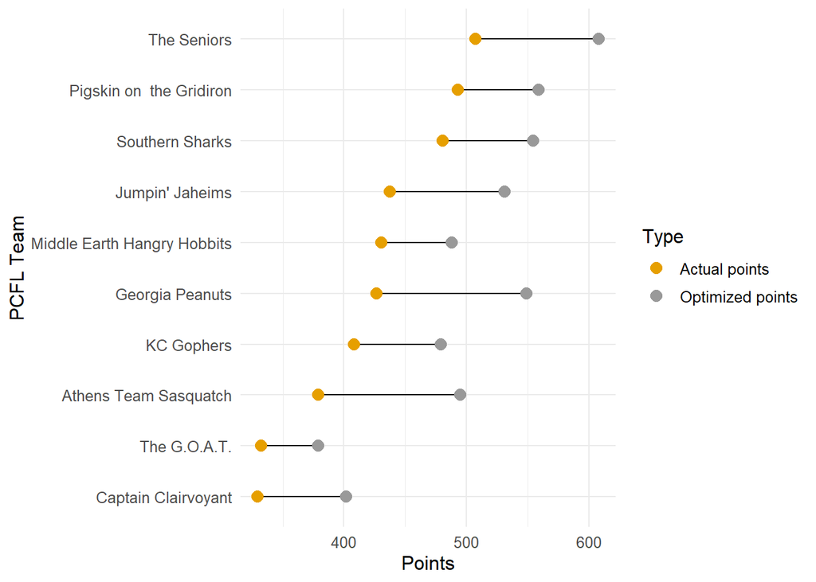

Seniors at the top for both actual and optimized points.

### Best pick-ups

There were 11 players added last week. Which was the **best pick-ups**?

| PCFL Team | Player | NFL Team | Position | Points |
| --- | --- | --- | --- | --- |
| KC Gophers | Seahawks D/ST | SEA | DST | 29.00 |
| Georgia Peanuts | De’Von Achane | MIA | RB | 25.50 |
| Athens Team Sasquatch | Khalil Herbert | CHI | RB | 20.20 |
| Georgia Peanuts | Jordan Love | GBP | QB | 17.64 |
| Georgia Peanuts | Ravens D/ST | BAL | DST | 17.00 |
| Georgia Peanuts | Adam Thielen | CAR | WR | 11.70 |
| The G.O.A.T. | Jayden Reed | GBP | WR | 9.00 |
| KC Gophers | Zach Ertz | ARI | TE | 8.30 |
| The G.O.A.T. | Michael Thomas | NOS | WR | 7.30 |
| Captain Clairvoyant | Patriots D/ST | NEP | DST | 2.00 |
| The Juniors | Joshua Palmer | LAC | WR | NA |

The Seahawks defense was something!

### Best team performances

Here’s a list of the **top five scoring performances** so far this season.

| PCFL Team | Week | Score | Result |
| --- | --- | --- | --- |
| Middle Earth Hangry Hobbits | 2 | 167.18 | W |
| Jumpin’ Jaheims | 4 | 149.98 | W |
| Georgia Peanuts | 4 | 148.64 | W |
| The Seniors | 3 | 146.88 | W |
| Pigskin on the Gridiron | 2 | 140.74 | W |

Scott still hanging tight at the top.

## Looking ahead

### League standings

| PCFL Team | Division | Points scored | Avg points | Avg last 3 | W | L | Team points |
| --- | --- | --- | --- | --- | --- | --- | --- |
| The Seniors | Hot Dish | 507.21 | 126.80 | 128.24 | 3 | 1 | 7 |
| Pigskin on the Gridiron | Grits | 493.10 | 123.28 | 123.15 | 4 | 0 | 7 |
| Southern Sharks | Hot Dish | 480.42 | 120.11 | 123.72 | 2 | 2 | 6 |
| Jumpin’ Jaheims | Grits | 437.44 | 109.36 | 115.93 | 2 | 2 | 4 |
| Middle Earth Hangry Hobbits | Hot Dish | 430.76 | 107.69 | 121.73 | 2 | 2 | 4 |
| KC Gophers | Hot Dish | 408.34 | 102.08 | 97.53 | 2 | 2 | 4 |
| Georgia Peanuts | Hot Dish | 426.62 | 106.66 | 117.49 | 1 | 3 | 3 |
| Athens Team Sasquatch | Grits | 379.00 | 94.75 | 90.07 | 2 | 2 | 3 |
| The G.O.A.T. | Grits | 332.52 | 83.13 | 85.29 | 1 | 3 | 1 |
| Captain Clairvoyant | Grits | 329.16 | 82.29 | 90.27 | 1 | 3 | 1 |

Seniors and Pigskin at the top, with the Sharks circling not far behind. Richard’s the only 4-0 team left.

### If the season ended today…

Seniors, Pigskin, and Sharks would be in. Jumpin’ Jaheims would win the tiebreaker for the last spot. But it’s still early.

### Next week’s matchups

| Team 1 | Team 2 |
| --- | --- |
| Athens Team Sasquatch (Avg. last 3: 90.07) | Jumpin’ Jaheims (Avg. last 3: 115.93) |
| Captain Clairvoyant (Avg. last 3: 90.27) | Southern Sharks (Avg. last 3: 123.72) |
| Georgia Peanuts (Avg. last 3: 117.49) | The Seniors (Avg. last 3: 128.24) |
| KC Gophers (Avg. last 3: 97.53) | Middle Earth Hangry Hobbits (Avg. last 3: 121.73) |
| Pigskin on the Gridiron (Avg. last 3: 123.15) | The G.O.A.T. (Avg. last 3: 85.29) |

We’ll see if Jacob can end his dad’s undefeated streak.

Good luck, y’all!